# Assignements network

Pedro Jordano

enero 19, 2015

[**Jordano’s lab R Figures Catalog**](https://github.com/PJordano-Lab/R-figures)

## Tree assignements example

Suppose we have a matrix (an adjacency matrix) with the number of tree genotypes resulting assigned to different populations within a region (e.g., a metapopulation). This plots the network of tree assignements so that we can better assess the connectivity patterns among them.

#### Data input

In this adjacency matrix we coded the number of immigrant/emigrant genotypes for tree populations `A`, `B`, `C`, and `D`, located within a given area. `OUT` represents the emigrant/immigrant genotypes to/from populations outside the area:

```r
require(igraph) # This loads the igraph package
# Direct input of adjacency matrix
#
# From: ->To:   | A  | B  | C  | D  | OUT
# --------------|----|----|----|----|----
# A             |110 |  0 | 4  | 0  | 7
# B             |  3 |  4 | 0  | 0  | 7
# C             | 29 | 15 | 10 | 18 | 3
# D             | 33 |  0 | 1  | 0  | 0
# OUT           |  4 |  5 | 2  | 1  | 16

myobject = data.frame(matrix(
    c(110, 0, 4, 0, 7,
      3, 4, 0, 0, 7,
      29, 15, 10, 18, 3,
      33, 0, 1, 0, 0,
      4, 5, 2, 1, 16),
    nrow=5,
    ncol=5,
    byrow = TRUE))
colnames(myobject)<-row.names(myobject)<- c("A","B","C","D","OUT")
```

Note that it is a square, asymmetric matrix, so that entries represent the number of immigrants from `row`population to `column`population. The diagonal cells are the number of genotypes actually in population `i`, inferred to come from that same population (i.e., originating from local, *in situ* dispersal events).

#### Plotting the network

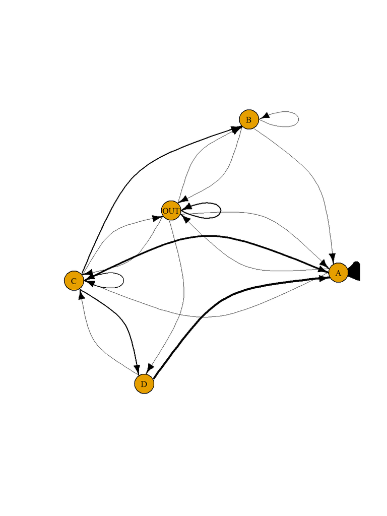

```r
m= as.matrix(myobject)              # coerces the data set as a matrix
g= graph.adjacency(m, mode="directed",
                   weighted=T, diag=T)        # this will create
                                              # an 'igraph object'
# Plotting the directed adjacency matrix.
plot.igraph(g, vertex.label= V(g)$name,
            layout=layout.fruchterman.reingold,
            vertex.label.color="black",
            vertex.label.cex=0.8,
            edge.color="black",
            edge.width=E(g)$weight/10,
            edge.arrow.size=0.8,
            edge.curved=TRUE)
```

#### References

1. Rannala, B. & Mountain, J. (1997). Detecting immigration by using multilocus genotypes. *Proceed. Natl. Acad. Sci. USA*, **94**: 9197–9201.
2. Dyer, R.J. & Nason, J.D. (2004). Population Graphs: the graph theoretic shape of genetic structure. *Molecular Ecology*, **13**: 1713–1727.